# Problem Set 12

### Heart Transplant Survivorship (PS 08)

For the data on survivorship after heart transplant, we had to transform the data due to unequal variances. That is not necessary when we use randomization. Reanalyze these data without transformation, testing the same hypothesis as you did in PS 08.

Refer to the key for PS 08 to refresh yourself with the question and adapt the code from the example above (either sequential or parallel). Otherwise we will leave this exercise undirected.

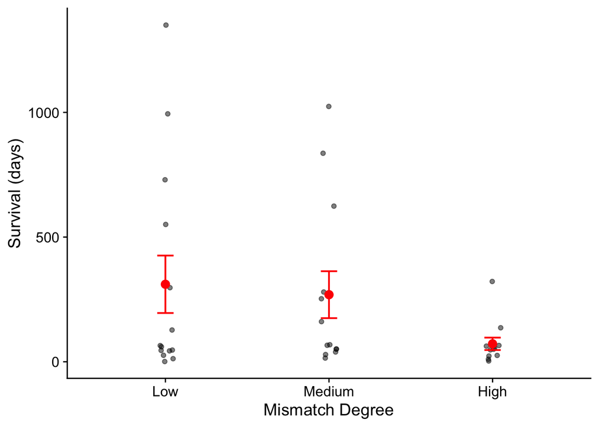

```r
# FIXME
HT <- read_excel("../data/Heart_Transplants.xlsx") |>
  mutate(Mismatch_Degree = fct_inorder(Mismatch_Degree))

ggplot(HT, aes(x = Mismatch_Degree, y = Survival_Days)) +
  geom_point(position = position_jitter(width = 0.05), alpha = 0.5) +
  stat_summary(fun.y = mean, geom = "point", size = 3, color = "red") +
  stat_summary(fun.data = mean_se, geom = "errorbar", width = 0.1,
               color = "red", size = 0.7) +
  labs(x = "Mismatch Degree", y = "Survival (days)")
```

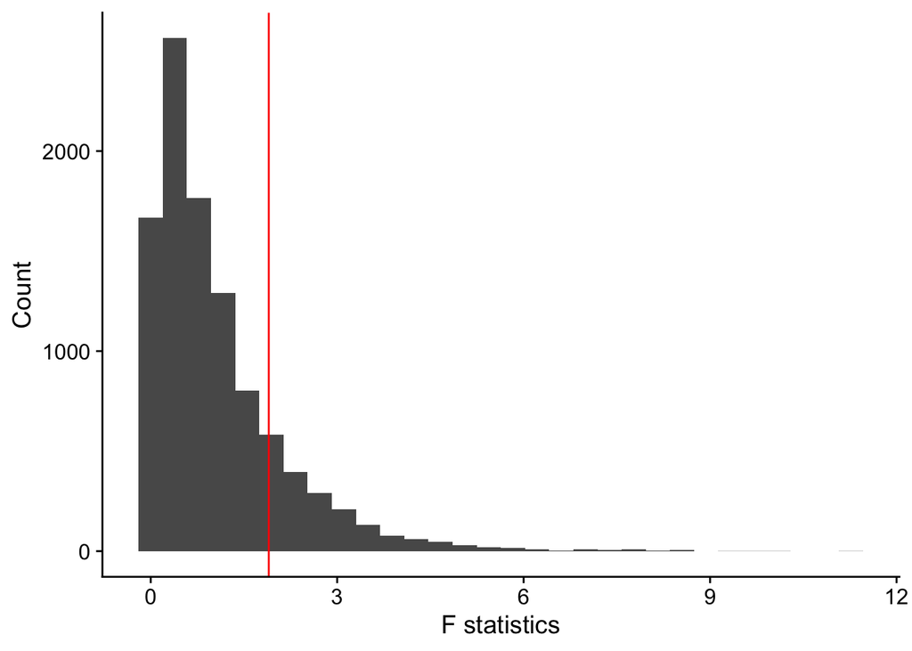

```r
fm <- lm(Survival_Days ~ Mismatch_Degree, data = HT)
obs <- summary(fm)

set.seed(823476)
nreps <- 1e4
F_stats <- numeric(nreps)
F_stats[1] <- obs$fstatistic["value"]

for (ii in 2:nreps) {
  fm_rand <- lm(sample(Survival_Days) ~ Mismatch_Degree,
                    data = HT)
  F_stats[ii] <- summary(fm_rand)$fstatistic["value"]
}

tibble(F_stats) |>
  ggplot(aes(F_stats)) +
  geom_histogram(bins = 30) +
  geom_vline(xintercept = F_stats[1], color = "red") +
  labs(x = "F statistics", y = "Count")
```

```r
mean(F_stats >= F_stats[1])
```

```
## [1] 0.166
```